# Goals

```
+-----+-----+
|month|count|
+-----+-----+
|    1|51005|
|    2|37766|
|    3|31337|
|    4|29667|
|    5|20340|
+-----+-----+
only showing top 5 rows
```

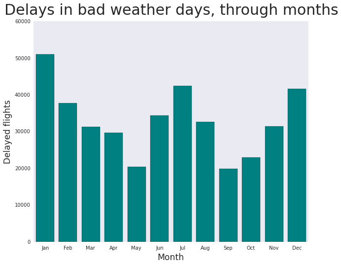

```python
# Delays per day of the month (BAD WEATHER)
delayed_per_month_badW = df_enhanced.filter((df_enhanced.arrival_delay > 15) & ((df_enhanced.thunderstorm == 1) | (df_enhanced.fog == 1) | (df_enhanced.rain == 1) | (df_enhanced.snow == 1))).groupBy('month').count().orderBy('month')
delayed_per_month_badW.show(5)

y_data = query_column(delayed_per_month_badW.collect(), 1)
barchart_simple("Delays in bad weather days, through months", MONTHS_SHORT, y_data, "Month", "Delayed flights")
```

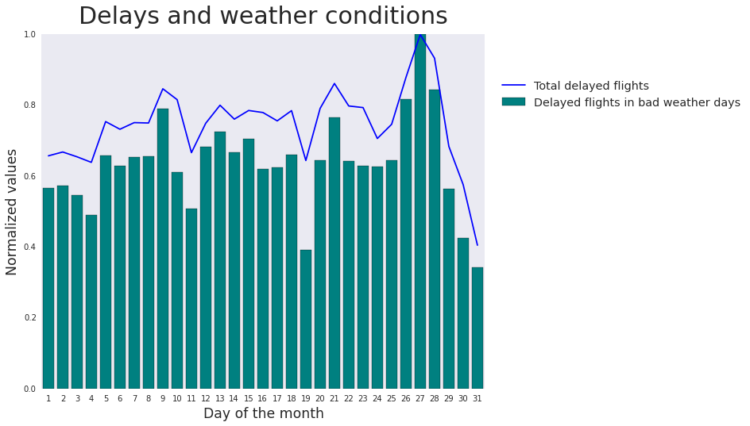

```python
bar_data = query_column(delayed_per_day_of_month_badW.collect(), 1)
line_data = query_column(delayed_per_day_of_month, 1)

barchart_and_linechart("Delays and weather conditions", DAYS_NUMBER, bar_data, line_data, "Day of the month", "Delayed flights in bad weather days", "Total delayed flights", box_x=1.6)
```

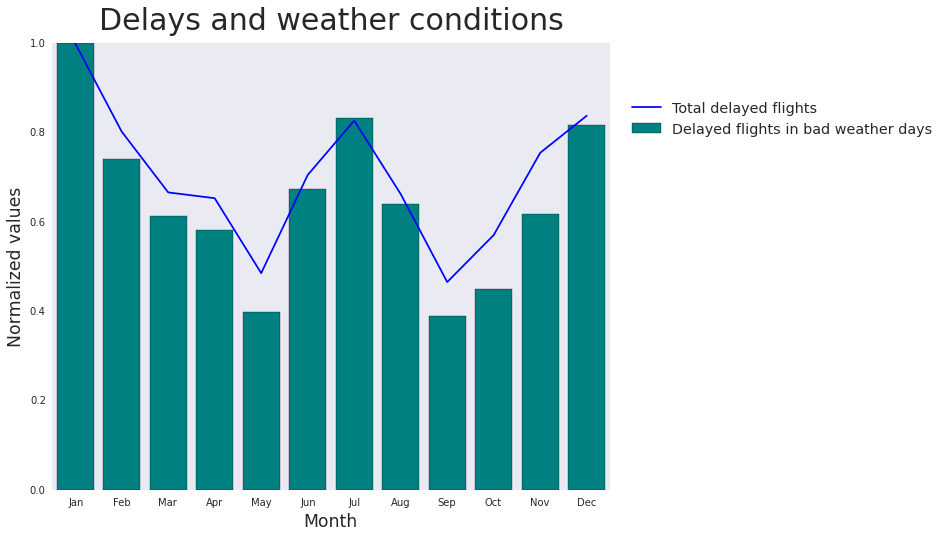

```python
bar_data = query_column(delayed_per_month_badW.collect(), 1)
line_data = query_column(delayed_per_month, 1)

barchart_and_linechart("Delays and weather conditions", MONTHS_SHORT, bar_data, line_data, "Month", "Delayed flights in bad weather days", "Total delayed flights", box_x=1.6)
```

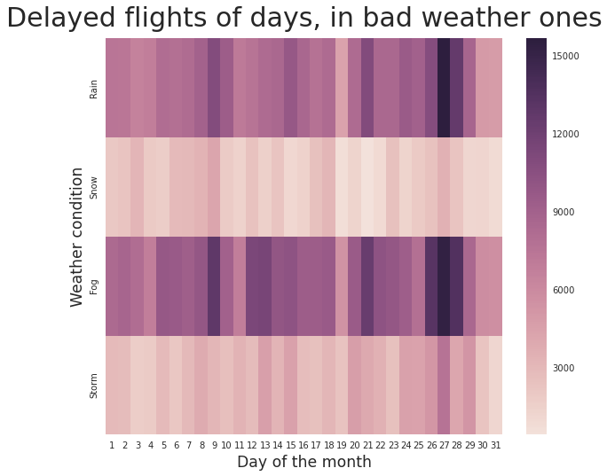

```python
grid_chart("Delayed flights of days, in bad weather ones", global_view_days, DAYS_NUMBER, wheaters, "Day of the month", "Weather condition")
```

**Interpretation**  
This is a quite representive graphs: we are now able to explain the strange peak of delays found before, very evident now, during the last days of the months (26-28)

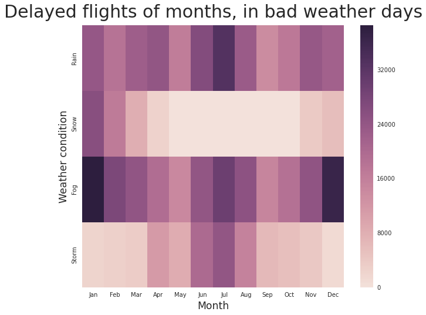

```python
grid_chart("Delayed flights of months, in bad weather days", global_view_months, MONTHS_SHORT, wheaters, "Month", "Weather condition")
```

**Interpretation**  
This graph is again usefult to have: we are now able to state that there actually is a correlation between seasons and delays, as supposed before.  
Also, we have now an alternative representation of the graphs about weather conditions drawn before